# Statistical Inference Project Part 2

Abhishek Kumar

9 August 2020

# Part 2: Basic Inferential Data Analysis

## Overview

Now in the second portion of the project, we're going to analyze the ToothGrowth data in the R datasets package. This analysis includes some basic exploratory analysis specifically summary and hypothesis testing confidence intervals.

```r
library(dplyr)
```

```r
library(ggplot2)
library(scales)
```

**1. Load the ToothGrowth data and perform some basic exploratory data analyses**

```r
data("ToothGrowth")
str(ToothGrowth)
```

```
## 'data.frame':    60 obs. of  3 variables:
##  $ len : num  4.2 11.5 7.3 5.8 6.4 10 11.2 11.2 5.2 7 ...
##  $ supp: Factor w/ 2 levels "OJ","VC": 2 2 2 2 2 2 2 2 2 2 ...
##  $ dose: num  0.5 0.5 0.5 0.5 0.5 0.5 0.5 0.5 0.5 0.5 ...
```

```r
ToothGrowth$dose <- as.factor(ToothGrowth$dose)
```

**About the data**

This data comes from a study which analyzed the effect of supplement (Vitamin C) on length of tooth in Guinea Pigs. This data has 60 observations and 3 variables (len, supp and dose). Each of 10 guinea pigs were given three Vitamin C dosage levels (0.5, 1, and 2 mg) with two delivery methods (orange juice or ascorbic acid). So, the data contains 60 observations of 3 variables.

- len : Tooth length
- supp : Supplement type (VC or OJ)
- dose : Dose in milligrams

## Exploratory Data Analysis

**2. Provide a basic summary of the data.**

```r
supp_summ <- ToothGrowth %>% group_by(Factor = supp) %>% summarise(mean = mean(len),
                                                   sd = sd(len),
                                                   median = median(len),
                                                   minimum = min(len),
                                                   maximum = max(len),
                                                   IQR = IQR(len))
dose_summ <- ToothGrowth %>% group_by(Factor = as.factor(dose)) %>% summarise(mean = mean(len),
                                                   sd = sd(len),
                                                   median = median(len),
                                                   minimum = min(len),
                                                   maximum = max(len),
                                                   IQR = IQR(len))
rbind(supp_summ, dose_summ)
```

```
## # A tibble: 5 x 7
##   Factor  mean    sd median minimum maximum   IQR
##   <fct>  <dbl> <dbl>  <dbl>   <dbl>   <dbl> <dbl>
## 1 OJ      20.7  6.61  22.7      8.2    30.9 10.2
## 2 VC      17.0  8.27  16.5      4.2    33.9 11.9
## 3 0.5     10.6  4.50   9.85     4.2    21.5  5.03
## 4 1       19.7  4.42  19.2     13.6    27.3  7.12
## 5 2       26.1  3.77  26.0     18.5    33.9  4.3
```

The basic summary indicates that the tooth length was ranged from 4.2 to 33.9 with a mean of 18.81 and Median of 19.25. Among groups the data is shown in above table.

**3. Use confidence intervals and/or hypothesis tests to compare tooth growth by supp and dose.**

1. Which supplementary method is more effective for tooth growth?

$H_0: \mu_{OJ} = \mu_{VJ}; \quad H_A: \mu_{OJ} \ne \mu_{VJ}$

```r
OJ <- (ToothGrowth %>% filter(supp == "OJ"))$len
VC <- (ToothGrowth %>% filter(supp == "VC"))$len

t.test(OJ, VC, paired = FALSE, var.equal = FALSE, conf.level = 0.95)
```

```
##
##  Welch Two Sample t-test
##
## data:  OJ and VC
## t = 1.9153, df = 55.309, p-value = 0.06063
## alternative hypothesis: true difference in means is not equal to 0
## 95 percent confidence interval:
##  -0.1710156  7.5710156
## sample estimates:
## mean of x mean of y
##  20.66333  16.96333
```

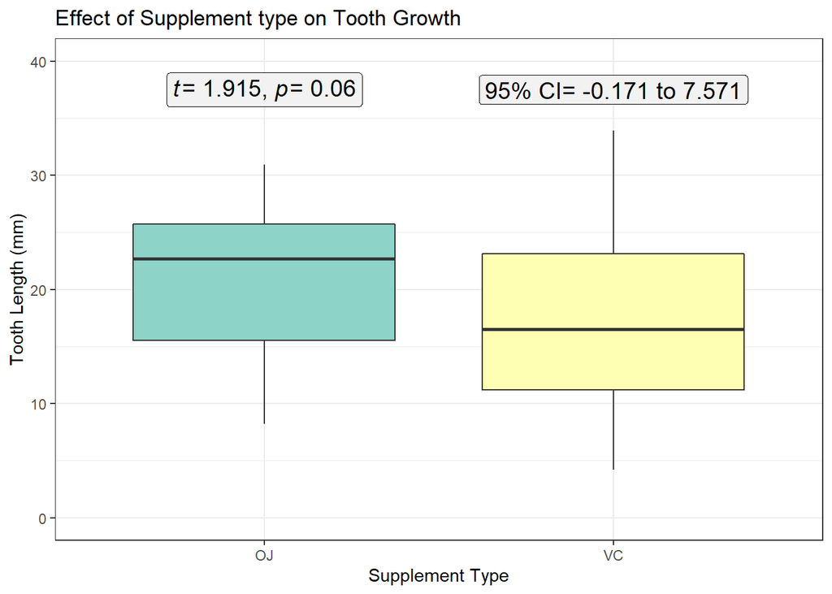

```r
ggplot(ToothGrowth, aes(x = supp, y = len, fill = supp)) +
      geom_boxplot(show.legend = FALSE) +
      scale_fill_brewer(palette = "Set3") +
      theme_bw() + ylim(0,40) +
      labs(x = "Supplement Type", y = "Tooth Length (mm)",
           title = "Effect of Supplement type on Tooth Growth") +
      geom_label(x = 1, y = 37.5, fill = "gray95", size = 5,
                label = "paste(italic(t), \"= 1.915\", \", \" , italic(p), \"= 0.06\")",
                parse = TRUE) +
      geom_label(x = 2, y = 37.5, fill = "gray95", size = 5,
                label = "paste(\"95% CI\", \"= -0.171 to 7.571\")",
                parse = TRUE)
```

So, the 95% confidence interval include zero suggesting that the null hypothesis ($H_0$) is true at this confidence interval and therefore, the alternative hypothesis ($H_A$) is rejected.

2. Which dose is more effective for tooth growth?

Lets consider that the doses 0.5, 1, and 2 represents the levels as Low, Medium and high.

Hypotheses:

$H_0: \mu_{Low} = \mu_{Medium} = \mu_{High}; \quad \\ H_A: \mu_{Low} \ne \mu_{Medium} \ne \mu_{High}$

```r
Low <- (ToothGrowth %>% filter(dose == "0.5"))$len
Medium <- (ToothGrowth %>% filter(dose == "1"))$len
High <- (ToothGrowth %>% filter(dose == "2"))$len

t.test(Low, Medium, paired = FALSE, var.equal = FALSE, conf.level = 0.95)
```

```
##
##  Welch Two Sample t-test
##
## data:  Low and Medium
## t = -6.4766, df = 37.986, p-value = 1.268e-07
## alternative hypothesis: true difference in means is not equal to 0
## 95 percent confidence interval:
##  -11.983781  -6.276219
## sample estimates:
## mean of x mean of y
##    10.605    19.735
```

```r
t.test(Low, High, paired = FALSE, var.equal = FALSE, conf.level = 0.95)
```

```
##
##  Welch Two Sample t-test
##
## data:  Low and High
## t = -11.799, df = 36.883, p-value = 4.398e-14
## alternative hypothesis: true difference in means is not equal to 0
## 95 percent confidence interval:
##  -18.15617 -12.83383
## sample estimates:
## mean of x mean of y
##    10.605    26.100
```

```r
t.test(High, Medium, paired = FALSE, var.equal = FALSE, conf.level = 0.95)
```

```
##
##  Welch Two Sample t-test
##
## data:  High and Medium
## t = 4.9005, df = 37.101, p-value = 1.906e-05
## alternative hypothesis: true difference in means is not equal to 0
## 95 percent confidence interval:
##  3.733519 8.996481
## sample estimates:
## mean of x mean of y
##    26.100    19.735
```

| Data | t | df | p-value | CI | x_mean | y_mean |
| --- | --- | --- | --- | --- | --- | --- |
| Low vs Medium | -6.477 | 37.986 | <0.000 | -11.98 to -6.276 | 10.60 | 19.73 |
| Low vs High | -11.799 | 36.883 | <0.000 | -18.16 to -12.834 | 10.60 | 26.10 |
| High vs Medium | 4.901 | 37.101 | <0.000 | 3.734 to 8.996 | 26.100 | 19.73 |

So, the 95% confidence interval did not included zero suggesting that the null hypothesis ($H_0$) is not true at this confidence interval and therefore, the alternative hypothesis ($H_A$) is accepted. Also, all the comparisons indicate a highly significant p-value showing the significant differences in the mean of the samples.

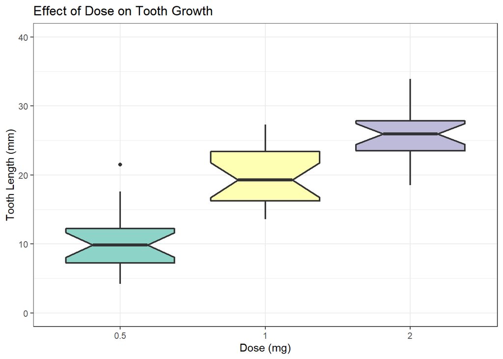

```r
ggplot(ToothGrowth, aes(x = as.factor(dose), y = len, fill = as.factor(dose))) +
      geom_boxplot(show.legend = FALSE, notch = TRUE, size = 0.75) +
      scale_fill_brewer(palette = "Set3") +
      theme_bw() + ylim(0,40) +
      labs(x = "Dose (mg)", y = "Tooth Length (mm)",
           title = "Effect of Dose on Tooth Growth")
```

### 4. State your conclusions and the assumptions needed for your conclusions.

#### Conclusions

The present analysis conclude that the tooth growth is not affected by supplement type (OJ or VC) at the 5% confidence intervals. However, the doses has the significant effects on the tooth growth, as the mean of doses was significantly differed among the dose concentrations.